# Aging 5 Years in 5 Minutes: The Effect of Taking a Memory Test on Older Adults’ Subjective Age (2013, Psychological Science)

Marc B. Harrison (marcharr@stanford.edu)

December 07, 2017

## Introduction

As we grow older our physical age may reflect one value while our internal or subjective sense of age may be younger or older. How one views their subjective age has been shown to impact psychological well-being and health (Barrett 2003, Stephan, Caudroit, & Chalabaev 2013). A recent study looked at how subjective age can be impacted by negative feedback during a cognitive task (Eibach, Mock, & Courtney 2010), with results suggesting that older adults attitudes about their abilities during a cognitive task can increase their subjective age (Eibach, Mock, & Courtney 2010). Importantly, does taking a memory test impact an older adults subjective age? To place this question in context, consider an older adult who selects to participate in a memory experiment at a college campus. They have to travel to a campus surrounded by younger students, where these same students collect demographic information, administer a baseline cognitive test to assess memory performance (e.g. mini mental state exam) and are finally are given a memory test. It is argued in Hughes et al. 2013 that this testing environment could potentially reinforce negative stereotypes through consistent classification of age for older adults. These factors led Hughes, Geraci & De Forrest to perform four experiments to assess if taking a memory test impacted subjective age in older adults.

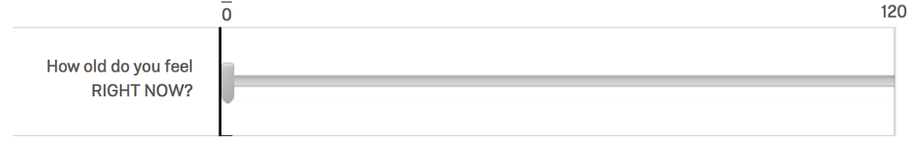

**Figure 1. Slider used in Study #3**

## Methods

Overall, methods followed those described in Hughes et al. 2013 and are briefly restated below.

### Power Analysis

In Hughes 2013, to test whether a subjective sense of age changed from pretest to post-test, a 2 (test type: memory vs. vocabulary) x 2 (time of report: pretest vs. post-test) mixed ANOVA was performed with a significant interaction between test type and time of report. This test was further refined by a planned t-test to quantify the interaction. Importantly, the effect size reported for the t-test was d=0.76. This value was used in the program G*Power3.1 under a two sample t-test a-prior setting to quantify how many participants would be required to obtain 80% power. Results indicated a sample size of 29 for memory, 29 for vocabulary would be sufficient to obtain 80% power. I chose to round to 30 for this replication. Older adults 55 or older living in the USA. This metric was obtained using a-priori two sided t-test with Gpower.

### Planned Sample

To obtain the critical power of 80% a Planned sample of 60 older adults above or at the age of 55 will be recruited through Amazon’s MTurk; 30 memory, 30 vocabulary. In addition, all subjects will be proficient in English and live within the United States.

### Materials

A survey implemented in Qualtrics will be used for this experiment in MTurk. Subjects will fill out a series of demographic questions and how they expect to perform during a memory or vocabulary test prior to the actual test. Prior to the start of the test, subjects will move a slider bar (Figure 1) to how they feel. Upon completion of subjective age rating, subjects will be randomized to either a memory or vocabulary test.The memory test will consist of 30 categorizable nouns to study for 3 minutes before being prompted to type all the words they can recall in a text box at the bottom of the computer screen. The vocabulary test will contain 44 questions, presented sequentially one at a time, where a target word must be matched to a similarly defined single word option out of four possible choices.